# Week 6 HW Zrutter

Zai Rutter

10/11/2021

## Question 1

First, load in the county_returns.csv, which contains the 2012 and 2016 presidential election returns by county. It also includes a variable for FIPS codes, which will help us later. a. Merge the county-level mapping data with this electoral data. Think carefully about how we should merge it! b. Create new variables: (1) clinton_prop (the proportion of the vote won by Hillary Clinton in the 2016 election), (2) trump_prop (the proportion of the vote won by Donald Trump in the 2016 election), and (3) clinton_won (an indicator variable telling you whether Hillary Clinton won a majority of the votes cast in this county).

```r
#A.
Question1_A <- county_with_income %>%
  full_join(county_returns, by = "fips")

#B
Question1_B <- Question1_A %>%
  mutate(clinton_prop = (clinton/total_votes_2016), trump_prop = (trump/total_votes_2016),
clinton_won = ifelse((clinton/total_votes_2016)>.50,"yes","no"))
```

## Question 2

[output not shown]

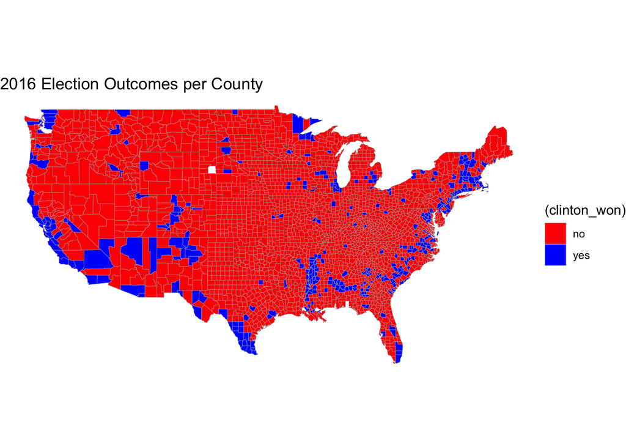

```r
ggplot() +
  geom_polygon(data = Question1_B, aes(x=long, y=lat, group=group,
                                       fill=(clinton_won)), col="dark grey", lwd=0.115) +
  coord_quickmap() +
  theme_void() +
  scale_fill_manual(values =c("red", "blue")) +
  labs(title = "2016 Election Outcomes per County")
```

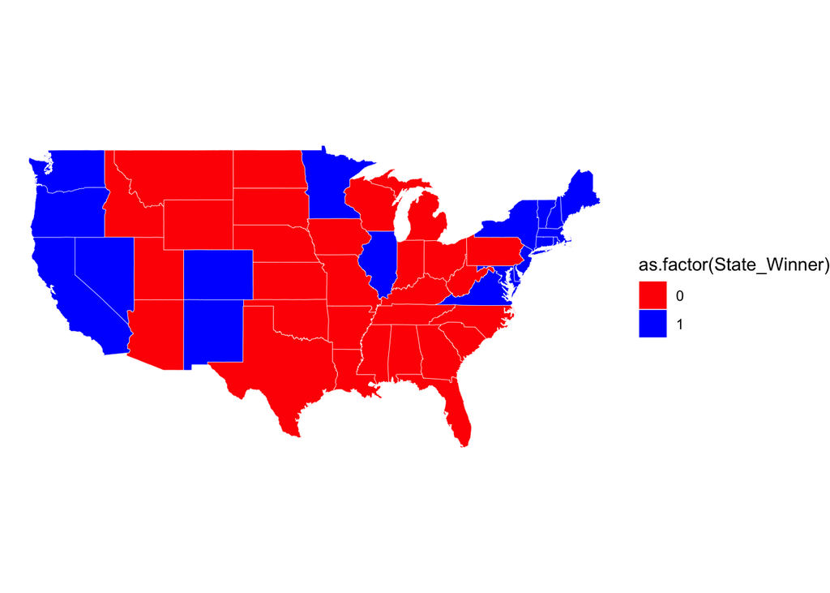

```r
States_Election <- county_returns %>%
  group_by(state.name) %>%
  summarise(Clinton_State_Winner = (sum(clinton)/(sum(clinton) + sum(trump)))) %>%
  mutate(State_Winner = ifelse(Clinton_State_Winner>.5,1,0)) %>%
  left_join(states, by=c("state.name" = "region"))

ggplot() +
  geom_polygon(data = States_Election, aes(x=long, y=lat, group=group,
                                       fill=as.factor(State_Winner)), col="white", lwd=0.115) +
  coord_quickmap() +
  theme_void() +
  scale_fill_manual(values =c("red", "blue"))
```

## Question 3

Now make a county-level map that shows the proportion of votes won by Hillary Clinton in the 2016 election. Counties should be colored on a sliding scale, with counties where Clinton won 0% of the vote in the brightest red, and counties where Clinton won 100% of the vote in the brightest blue. Make these counties fade to white in the middle, so that the color fades as the margin of victory decreases.

1. Now draw the same map, except us the more familiar red –> purple –> blue maps that you often see in election analyses. So heavily Trump areas are bright red, politically mixed areas are purple, and heavily Democratic areas are deep blue. Which of these maps do you prefer, and why?

**Answer**

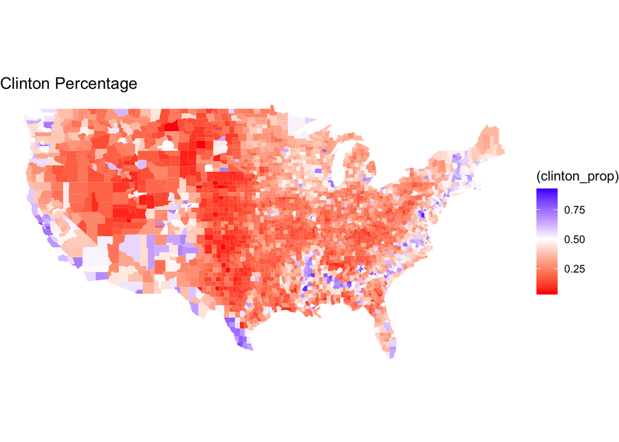

```r
ggplot() +
  geom_polygon(data = Question1_B, aes(x=long, y=lat, group=group, fill=(clinton_prop))) +
  coord_quickmap() +
  theme(legend.position="none") +
  theme_void() +
  scale_fill_gradient2(high = "blue", mid = "white", low = "red", midpoint = .5) +
  ggtitle("Clinton Percentage")
```

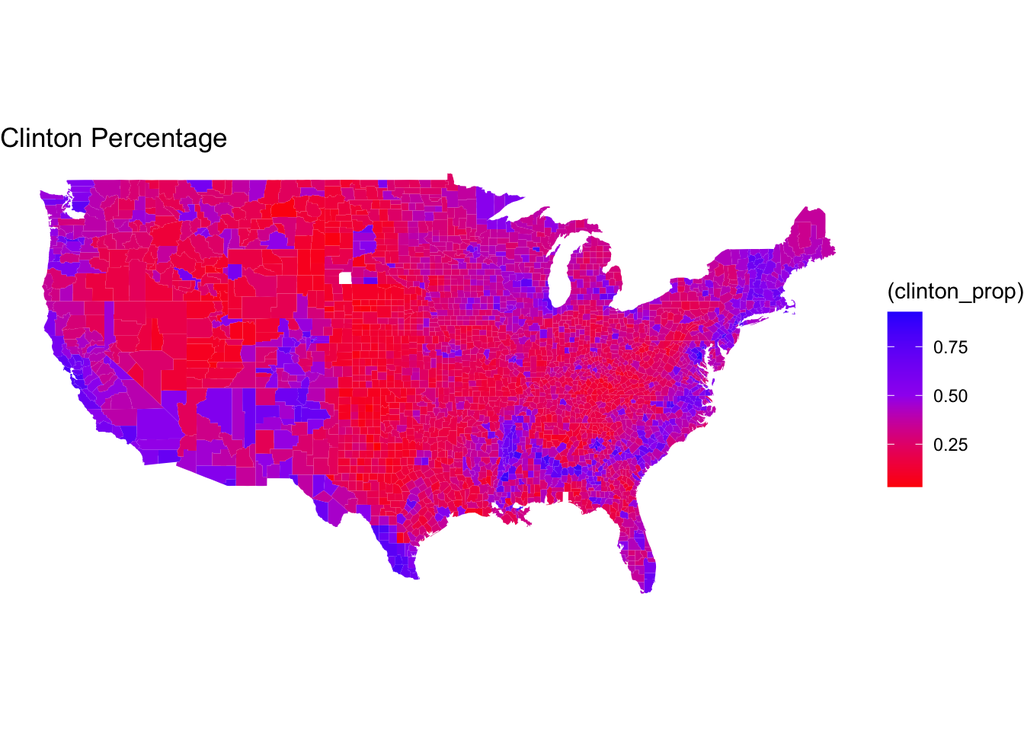

```r
ggplot() +
  geom_polygon(data = Question1_B, aes(x=long, y=lat, group=group, fill=(clinton_prop))) +
  coord_quickmap() +
  theme(legend.position="none") +
  theme_void() +
  scale_fill_gradient2(high = "blue", mid = "purple", low = "red", midpoint = .5) +
  ggtitle("Clinton Percentage")
```

## Question 4

Now use the 2012 data we included to calculate the swing from 2012 to 2016. Where did Clinton improve on Obama’s performance, and where did it fall off? Places where Clinton did better than Obama should be more blue and places where she did worse should be more red. Comment on your results and where you see trends.

**Answer**

I was very surprised to see that Clinton did better in southern states. But again it makes sense since she was more right leaning.

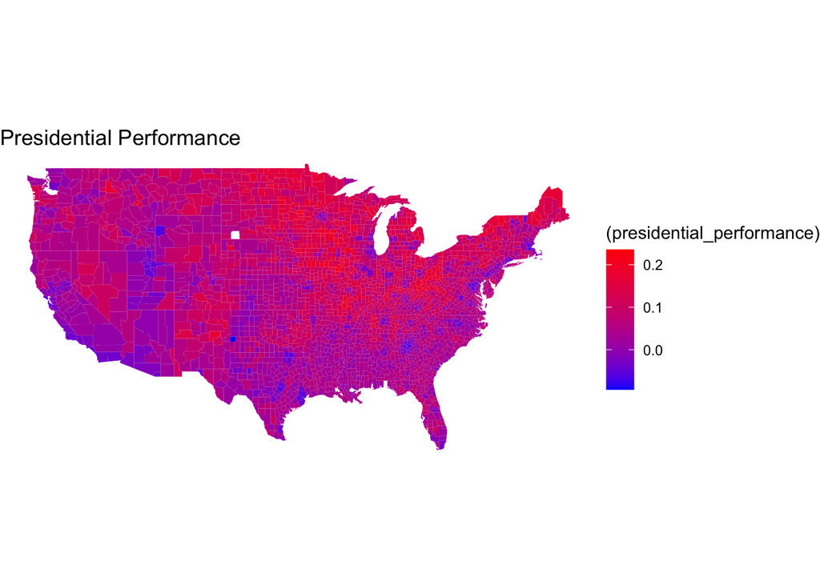

```r
Question4 <- Question1_B %>%
  mutate(obama_prop = obama/total_votes_2012) %>%
  mutate(presidential_performance = obama_prop - clinton_prop)

ggplot() +
  geom_polygon(data = Question4, aes(x=long, y=lat, group=group, fill=(presidential_performance))) +
  coord_quickmap() +
  theme(legend.position="none") +
  theme_void() +
  scale_fill_gradient(high = "red", low = "blue") +
  ggtitle("Presidential Performance")
```